# CP04

Jose López Galdón

2020-11-11

## CARGAMOS LOS DATOS

Visualizamos los datos.

```r
raw_data
```

```
##    Trimestre Ingresos
## 1    Q2 2008     7980
## 2    Q3 2008     7561
## 3    Q4 2008    11520
## 4    Q1 2009    11880
## 5    Q2 2009     9084
## 6    Q3 2009     9734
## 7    Q4 2009    12207
## 8    Q1 2010    15683
## 9    Q2 2010    13499
## 10   Q3 2010    15700
## 11   Q4 2010    20343
## 12   Q1 2011    26741
## 13   Q2 2011    24667
## 14   Q3 2011    28571
```

[output cut: 24 more lines]

## LIMPIEZA DEL DATASET

### Fechas

Como podemos observar la columna trismetes incluye también el año con el siguiente formato: `Qn yyyy` siendo *n* el número del trismetre y siendo *yyyy* el año. Para solucionar este problema transformaremos esta columna a formato fecha:

```r
  # Comenzamos pasando a fechas nuestra columna "Trimestre"
fechas <- seq(as.Date("2008-04-01"), as.Date("2017-09-30"), by = "quarter")
fechas
```

```
##  [1] "2008-04-01" "2008-07-01" "2008-10-01" "2009-01-01" "2009-04-01"
##  [6] "2009-07-01" "2009-10-01" "2010-01-01" "2010-04-01" "2010-07-01"
## [11] "2010-10-01" "2011-01-01" "2011-04-01" "2011-07-01" "2011-10-01"
## [16] "2012-01-01" "2012-04-01" "2012-07-01" "2012-10-01" "2013-01-01"
## [21] "2013-04-01" "2013-07-01" "2013-10-01" "2014-01-01" "2014-04-01"
## [26] "2014-07-01" "2014-10-01" "2015-01-01" "2015-04-01" "2015-07-01"
## [31] "2015-10-01" "2016-01-01" "2016-04-01" "2016-07-01" "2016-10-01"
## [36] "2017-01-01" "2017-04-01" "2017-07-01"
```

```r
  # Podemos comprobar que está bien haciendo la diferencia entre los elementos de "fechas" y el número de observaciones del df original

length(fechas) - nrow(raw_data)
```

```
## [1] 0
```

Une vez tenemos las 38 nuevas fechas, pasamos a tiempo contínuo lo base de datos:

```r
  # Primero eliminamos la columna trimestre, para cambiar a formato trimestra con nuestro vector "fechas"
raw_data %<>% select(-Trimestre)

  # Aplicamos la función xts() con el objtivo de pasarlo a tiempo contínuo
data <- xts(raw_data, order.by = fechas)

  # Transformamos las fechas a formarto trimestre
x_data <- to.quarterly(data)

  # Visualizamos el resultado
x_data
```

```
##         data.Open data.High data.Low data.Close
## 2008 Q2      7980      7980     7980       7980
## 2008 Q3      7561      7561     7561       7561
## 2008 Q4     11520     11520    11520      11520
## 2009 Q1     11880     11880    11880      11880
## 2009 Q2      9084      9084     9084       9084
## 2009 Q3      9734      9734     9734       9734
## 2009 Q4     12207     12207    12207      12207
## 2010 Q1     15683     15683    15683      15683
## 2010 Q2     13499     13499    13499      13499
## 2010 Q3     15700     15700    15700      15700
## 2010 Q4     20343     20343    20343      20343
## 2011 Q1     26741     26741    26741      26741
## 2011 Q2     24667     24667    24667      24667
## 2011 Q3     28571     28571    28571      28571
```

[output cut: 24 more lines]

```r
  # Como en ciertos paquetes no funciona xts, lo pasaremos a formato zoo con la librería forecast para no tener problemas y cogemos el precio de cierre

z_data = as.zoo(x_data$data.Close)

  # Cambiamos el nombre de la columna
names(z_data) <- "Ingresos"

  # Visualizamos el resultado
z_data
```

```
##         Ingresos
## 2008 Q2     7980
## 2008 Q3     7561
## 2008 Q4    11520
## 2009 Q1    11880
## 2009 Q2     9084
## 2009 Q3     9734
## 2009 Q4    12207
## 2010 Q1    15683
## 2010 Q2    13499
## 2010 Q3    15700
## 2010 Q4    20343
## 2011 Q1    26741
## 2011 Q2    24667
## 2011 Q3    28571
```

[output cut: 24 more lines]

Una vez tenemos la base de datos, ya estamos listos para trabajar!

## Sub-muestra

Primero divideremos la muestra, dejando fuera los datos del 2017…

```r
  # Quitamos los 3 últimos datos, que son los del 2017
c_omit = 3

  # Tamaño del dataset
n = length(z_data)

  # Creamos la sub muestra sin los 3 últimos cuatrimestres
o_ingresos <- window(x = z_data, start = index(z_data[1]),
                     end = index(z_data[n - c_omit])
                     )
  # Viusalizamos el resultado
o_ingresos
```

```
##         Ingresos
## 2008 Q2     7980
## 2008 Q3     7561
## 2008 Q4    11520
## 2009 Q1    11880
## 2009 Q2     9084
## 2009 Q3     9734
## 2009 Q4    12207
## 2010 Q1    15683
## 2010 Q2    13499
## 2010 Q3    15700
## 2010 Q4    20343
## 2011 Q1    26741
## 2011 Q2    24667
## 2011 Q3    28571
```

[output cut: 21 more lines]

Como podemos observar, `o_ingresos` solo tiene los datos hasta 2016.

## Selección automática del modelo ETS

```r
  # Mediante el comando ets() de la librería forecast podemos calcular automáticamente el mejor modelo ETS
ets <- ets(o_ingresos)

  # Observamos el modelo
summary(ets)
```

```
## ETS(M,A,M)
##
## Call:
##  ets(y = o_ingresos)
##
##   Smoothing parameters:
##     alpha = 0.493
##     beta  = 0.493
##     gamma = 0.507
##
##   Initial states:
##     l = 7125.3462
##     b = 1485.7975
##     s = 1.1511 1.1163 0.8322 0.9004
##
##   sigma:  0.1222
##
##      AIC     AICc      BIC
## 703.9538 711.1538 717.9519
##
## Training set error measures:
##                   ME     RMSE      MAE       MPE     MAPE      MASE      ACF1
## Training set -41.934 4120.155 2883.262 -0.297759 8.677434 0.4160202 0.1438481
```

Con la selección automática de ETS tenemos un modelo con un MAPE (*Mean Absolute Percentage Error*) de 8.677434 y un RMSE (*Root Mean Squared Error*) de 4120.155.

## Selección automática del modelo ARIMA

```r
  # Mediante el comando auto.arima() de la librería forecast podemos calcular automáticamente el mejor modelo ARIMA
arima = auto.arima(o_ingresos)

summary(arima)
```

```
## Series: o_ingresos
## ARIMA(1,0,0)(0,1,0)[4]
##
## Coefficients:
##          ar1
##       0.8331
## s.e.  0.0876
##
## sigma^2 estimated as 20474541:  log likelihood=-305.01
## AIC=614.02   AICc=614.45   BIC=616.89
##
## Training set error measures:
##                    ME     RMSE      MAE      MPE     MAPE      MASE       ACF1
## Training set 716.2193 4189.225 2797.277 2.986021 8.038297 0.4036137 0.05639445
```

En nuestro caso vamos a seleccionar el modelo por el MAPE: es una medida de la precisión de la predicción de un método de predicción en estadísticas, por ejemplo en la estimación de tendencias, que también se utiliza como función de pérdida para problemas de regresión en el aprendizaje automático.

Es por ello que seleccionamos el modelo ARIMA:

## Predicción con el modelo ARIMA

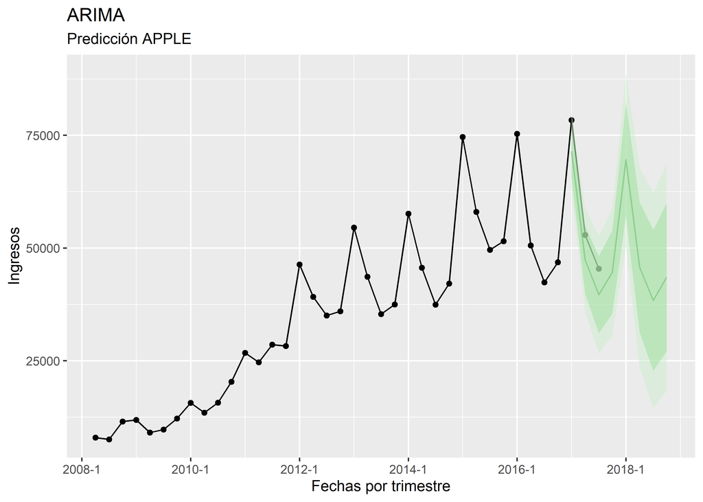

```r
  # Realizamos la predicción del modelo ARIMA
prediccion_ingresos = forecast(arima)

  # Nos definimos un dataframe para el plot
plot_data <- data.frame(value = as.vector(z_data),
                        time = time(z_data))

  # Realizamos la representación gráfica
ggplot(plot_data) +                                          # ploteamos con nuestra base de datos nueva (plot_data)
  geom_point(aes(x = time, y = value)) +                     # capa con los puntos
  geom_line(aes(x = time, y = value)) +                      # nueva capa con las líneas que unen los puntos
    autolayer(prediccion_ingresos, alpha = 0.5 ,             # con la función autolayer() dibujamos la predicción, aplha para la transparencia
              col = "forestgreen") +                         # col = cambiamos el color de la pred
      labs(title = "ARIMA", subtitle = "Predicción APPLE",   # Estblecemos los títulos
           x = "Fechas por trimestre", y = "Ingresos")
```

Como podemos observar nuestra predicción se ha acercado a lo que ocurrió en la realidad pero desde una perspectiva más pesimista, ya que la caída de los ingresos predicha es mayor que lo ocurrido durante los tres tirmestres del 2017.

Por último, incluiremos una tabla con los datos de las predicciones obtenidas:

```r
  # Creamos un DF con los últimos valores tres valores reales y nuestra predicción

prediccion_ingresos
```

```
##         Point Forecast    Lo 80    Hi 80    Lo 95    Hi 95
## 2017 Q1       71450.81 65651.94 77249.68 62582.21 80319.41
## 2017 Q2       47330.16 39782.50 54877.81 35787.02 58873.30
## 2017 Q3       39669.64 31115.85 48223.43 26587.74 52751.54
## 2017 Q4       44612.27 35424.67 53799.86 30561.05 58663.48
## 2018 Q1       69584.84 57005.32 82164.35 50346.13 88823.54
## 2018 Q2       45775.57 31301.78 60249.36 23639.82 67911.33
## 2018 Q3       38374.48 22720.07 54028.89 14433.13 62315.83
## 2018 Q4       43533.24 27109.19 59957.29 18414.82 68651.65
```

## CONCLUSIONES

Podemos observar como la tendencia de los ingresos de APPLE es amortiguada, es decir, observamos un rápido crecimiento durante las primeras etapas (2008 - 2012) y después un estancamiento de estos ingresos… ¿Por qué ocurre esto?

En el año 2016 la empresa anunció su primer caída de los ingresos desde el 2001, el motivo de esta caída es el descenso de ventas en el iPhone, el iPad y los Mac que como podemos observar en el grádico situado más abajo eran las principales fuentes de ingresos de la compañía, uno de los posibles motivos fue la falta de innovación en sus productos, esto sumado a un descenso del 30% de las ventas en China explican la caída del gigante estadounidense.

[figure not shown]

## Referencias

Jiménez, M. (2016, 26 octubre). Apple, ¿a la espera de la remontada en 2017? Cinco Días. Recuperado de https://cincodias.elpais.comRoa

M. M. (2020, 10 noviembre). ¿Cuánto ha crecido Apple en el siglo XXI? Recuperado de https://es.statista.com/grafico/23450/ingresos-de-apple-por-segmentos/